# Spatial Mixed Models for Field Trials

mixedFlowR tutorial series

# 1 Purpose

Agronomic field trials are rarely spatially homogeneous. Soil depth, fertility, moisture, slope, compaction, previous management, and microrelief can create trends across rows and columns. If treatment allocation is superimposed on these gradients, ignoring spatial structure can reduce precision or confound treatment interpretation.

`mixedFlowR` provides two complementary spatial routes:

1. parametric spatial covariance through `glmmTMB`;
2. two-dimensional P-spline field correction through `SpATS` (Rodriguez-Alvarez et al. 2018).

# 2 1. Learning objectives

You will learn to:

- map raw field observations before modeling;
- distinguish block effects from continuous spatial trend;
- fit exponential, Gaussian, and Matérn spatial covariance structures;
- fit a two-dimensional P-spline field model with `SpATS`;
- extract and visualize the spatial surface;
- compare raw and spatially adjusted interpretations;
- recognize spatial-treatment confounding;
- report spatial models transparently.

# 3 2. Spatial teaching data

```r
library(mixedFlowR)
s <- mixed_data("spatial")
head(s)
```

```
#>   row col block genotype    yield
#> 1   1   1    B1      G01 73.66958
#> 2   1   2    B1      G02 56.49528
#> 3   1   3    B1      G03 73.13840
#> 4   1   4    B1      G04 67.46671
#> 5   1   5    B1      G05 67.64908
#> 6   1   6    B1      G06 73.50994
```

Inspect dimensions and support.

```r
range(s$row)
```

```
#> [1]  1 12
```

```r
range(s$col)
```

```
#> [1]  1 18
```

```r
length(unique(s$genotype))
```

```
#> [1] 12
```

```r
with(s, table(block))
```

```
#> block
#> B1 B2 B3
#> 72 72 72
```

# 4 3. Raw field map

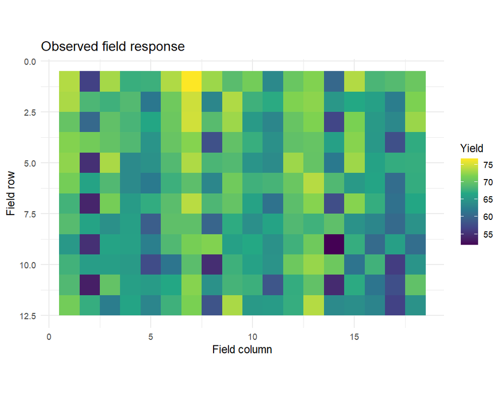

```r
if (requireNamespace("ggplot2", quietly = TRUE)) {
  ggplot2::ggplot(s, ggplot2::aes(col, row, fill = yield)) +
    ggplot2::geom_tile() +
    ggplot2::scale_fill_viridis_c() +
    ggplot2::coord_equal() +
    ggplot2::scale_y_reverse() +
    ggplot2::labs(
      x = "Field column",
      y = "Field row",
      fill = "Yield",
      title = "Observed field response"
    ) +
    ggplot2::theme_minimal(base_size = 11)
}
```

**How to read the figure.** Look for broad gradients, patches, row/column bands, local extremes, and whether treatment layout might align with the gradient. This map is descriptive and mixes treatment signal with spatial variation.

# 5 4. Raw genotype means are not spatially adjusted

```r
raw_gen <- aggregate(yield ~ genotype, s, mean)
raw_gen[order(-raw_gen$yield), ][1:8, ]
```

```
#>    genotype    yield
#> 7       G07 72.05900
#> 1       G01 70.60475
#> 3       G03 70.57550
#> 6       G06 69.07962
#> 12      G12 68.05121
#> 8       G08 67.96433
#> 9       G09 67.08520
#> 10      G10 66.19976
```

These means are useful for reconnaissance, not final genotype ranking if spatial trend is important.

# 6 5. Parametric spatial covariance

Fit an exponential covariance structure.

```r
if (requireNamespace("glmmTMB", quietly = TRUE)) {
  m_exp <- mixed_spatial_covariance(
    data      = s,
    response  = "yield",
    fixed     = "genotype + block",
    x         = "col",
    y         = "row",
    structure = "exp"
  )

  m_exp
}
```

```
#> $call
#> mixed_spatial_covariance(data = s, response = "yield", fixed = "genotype + block",
#>     x = "col", y = "row", structure = "exp")
#>
#> $engine
#> [1] "glmmTMB"
#>
#> $model
#> Formula:
#> yield ~ genotype + block + exp(.mf_pos + 0 | .mf_spatial_group)
#> Data: ..mf_data
#>       AIC       BIC    logLik -2*log(L)  df.resid
#>  976.7978 1034.1775 -471.3989  942.7978       199
#> Random-effects (co)variances:
#>
```

[output cut: 285 more lines]

Gaussian covariance:

```r
if (requireNamespace("glmmTMB", quietly = TRUE)) {
  m_gau <- mixed_spatial_covariance(
    s, "yield", "genotype + block", "col", "row",
    structure = "gau"
  )
}
```

Matérn covariance:

```r
if (requireNamespace("glmmTMB", quietly = TRUE)) {
  m_mat <- mixed_spatial_covariance(
    s, "yield", "genotype + block", "col", "row",
    structure = "mat"
  )
}
```

# 7 6. Compare parametric spatial candidates

```r
if (exists("m_exp") && exists("m_gau") && exists("m_mat")) {
  mixed_covariance_compare(
    Exponential = m_exp,
    Gaussian    = m_gau,
    Matern      = m_mat
  )
}
```

```
#>         model  engine      AIC      BIC    logLik
#> 1 Exponential glmmTMB 976.7978 1034.177 -471.3989
#> 2    Gaussian glmmTMB       NA       NA        NA
#> 3      Matern glmmTMB       NA       NA        NA
```

Do not choose a covariance solely because it has the smallest AIC. Consider estimated range/smoothness, residual spatial structure, convergence, and field-scale plausibility.

# 8 7. Diagnose the parametric model

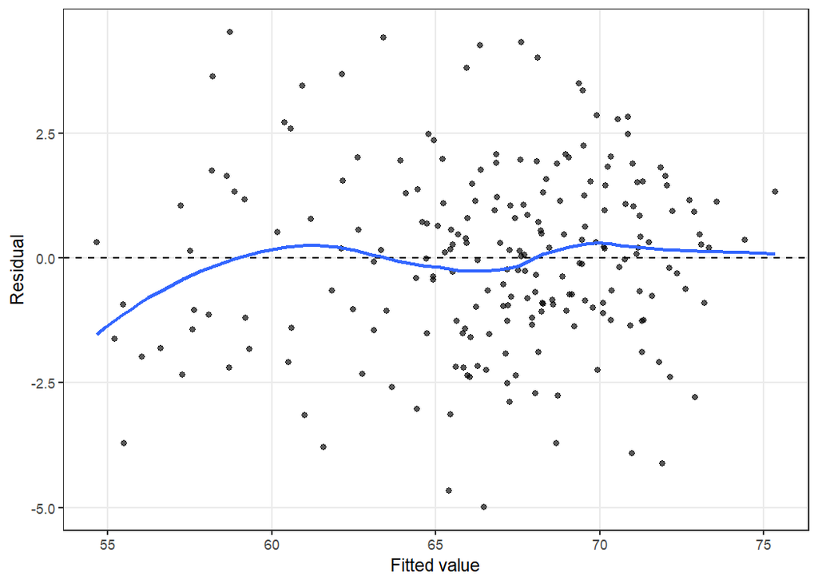

```r
if (exists("m_exp")) {
  mixed_diagnose(m_exp)
  mixed_plot(m_exp, type = "residuals")
}
```

If spatial dependence remains after the model, the covariance structure may be inadequate or the mean model may be missing field structure.

# 9 8. Two-dimensional P-spline field model with SpATS

```r
if (requireNamespace("SpATS", quietly = TRUE)) {
  spats_fit <- mixed_spatial_field(
    data     = s,
    response = "yield",
    genotype = "genotype",
    col      = "col",
    row      = "row",
    random   = ~ block,
    nseg     = c(6, 6)
  )

  spats_fit
}
```

```
#> Effective dimensions
#> -------------------------
#> It.     Deviance       block      f(col)      f(row)  f(col):row  col:f(row)f(col):f(row)
#>   1   884.844493       0.279       1.618       1.685       1.322       1.321       3.325
#>   2   537.403262       0.307       1.976       1.851       1.030       0.792       3.014
#>   3   536.917191       0.334       1.967       1.945       0.906       0.414       2.960
#>   4   536.722680       0.351       1.967       2.002       0.849       0.194       2.987
#>   5   536.643158       0.358       1.967       2.038       0.819       0.087       3.045
#>   6   536.607794       0.359       1.967       2.062       0.799       0.038       3.108
#>   7   536.591020       0.357       1.967       2.078       0.784       0.016       3.168
#>   8   536.582677       0.352       1.966       2.090       0.772       0.007       3.221
#>   9   536.578309       0.347       1.966       2.099       0.762       0.003       3.266
#>  10   536.575874       0.342       1.966       2.107       0.753       0.001       3.303
#>  11   536.574419       0.336       1.966       2.114       0.746       0.000       3.335
#>  12   536.573493       0.331       1.966       2.119       0.739       0.000       3.362
```

[output cut: 271 more lines]

The spatial surface is modeled with a two-dimensional penalized spline rather than a single parametric correlation-decay function.

# 10 9. Extract the fitted spatial trend

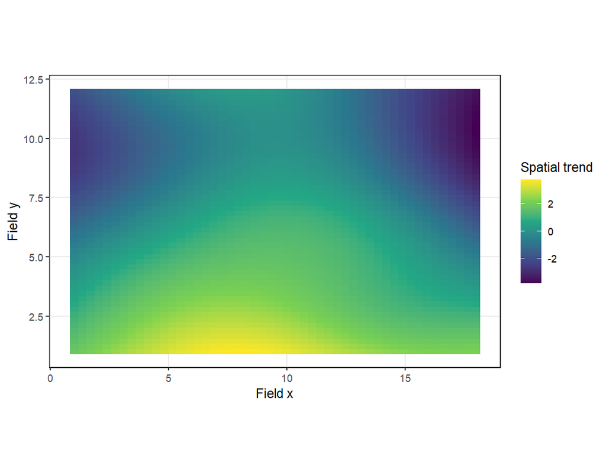

```r
if (exists("spats_fit")) {
  surface <- mixed_spatial_surface(
    spats_fit,
    grid = c(50, 50)
  )

  surface$plot
}
```

**How to read the figure.** The heat map represents the estimated spatial trend, not genotype performance. A field trend can reveal gradual fertility or moisture structure and local patches.

# 11 10. Publication wrapper for the same surface

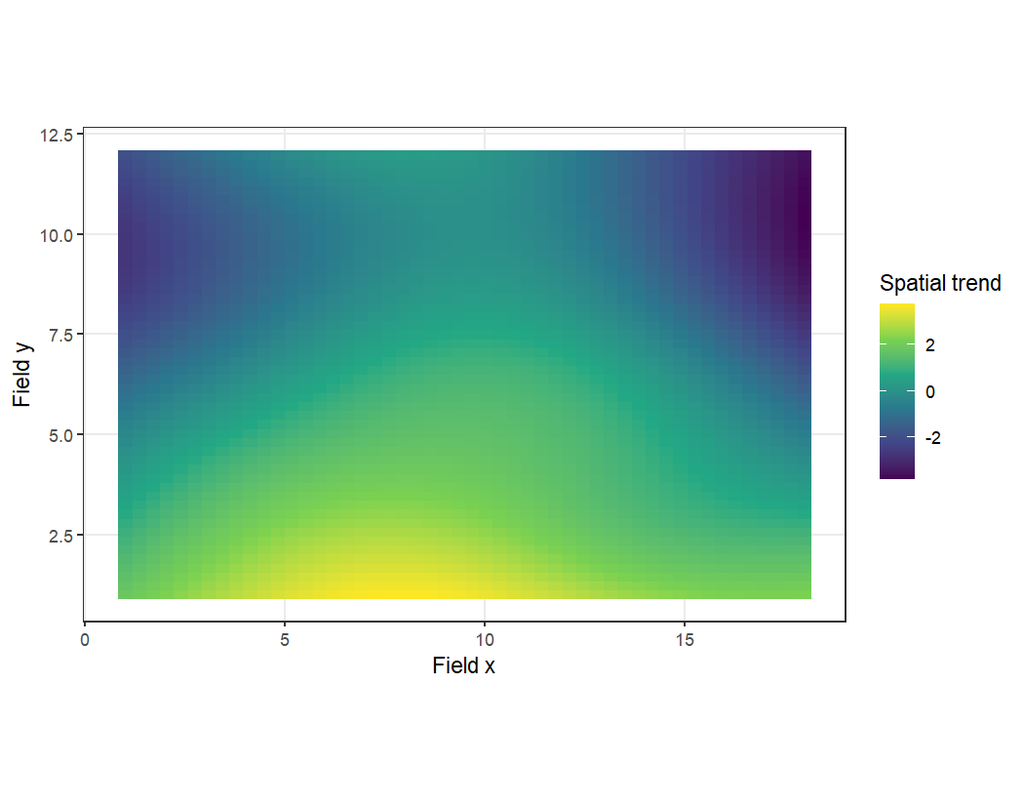

```r
if (exists("spats_fit")) {
  mixed_plot(
    spats_fit,
    type = "spatial"
  )
}
```

# 12 11. Genotype as random

In breeding contexts, the target can be prediction of genotype effects rather than fixed comparisons.

```r
if (requireNamespace("SpATS", quietly = TRUE)) {
  spats_random <- mixed_spatial_field(
    s,
    response = "yield",
    genotype = "genotype",
    col = "col",
    row = "row",
    random = ~ block,
    genotype_as_random = TRUE,
    nseg = c(6, 6)
  )
}
```

```
#> Effective dimensions
#> -------------------------
#> It.     Deviance    genotype       block      f(col)      f(row)  f(col):row  col:f(row)f(col):f(row)
#>   1  1069.097107      10.403       0.279       1.624       1.685       1.323       1.321       3.327
#>   2   582.362617      10.841       0.305       1.960       1.847       1.048       0.796       2.996
#>   3   581.847131      10.849       0.333       1.965       1.942       0.919       0.419       2.938
#>   4   581.649929      10.849       0.350       1.965       2.000       0.859       0.198       2.966
#>   5   581.568828      10.849       0.358       1.965       2.037       0.827       0.089       3.026
#>   6   581.532466      10.849       0.360       1.965       2.061       0.806       0.039       3.092
#>   7   581.515054      10.849       0.357       1.965       2.077       0.791       0.016       3.154
#>   8   581.506310      10.850       0.353       1.965       2.089       0.778       0.007       3.209
#>   9   581.501691      10.850       0.347       1.965       2.099       0.767       0.003       3.256
#>  10   581.499097      10.850       0.342       1.964       2.107       0.758       0.001       3.295
#>  11   581.497538      10.850       0.336       1.964       2.113       0.750       0.000       3.328
#>  12   581.496542      10.850       0.331       1.964       2.119       0.743       0.000       3.356
#> Timings:
#> SpATS 0.03 seconds
#> All process 0.03 seconds
```

Whether genotype should be fixed or random depends on the target population and inferential objective.

# 13 12. Sensitivity to spatial basis resolution

```r
if (requireNamespace("SpATS", quietly = TRUE)) {
  spats_fine <- mixed_spatial_field(
    s,
    "yield",
    "genotype",
    "col",
    "row",
    random = ~ block,
    nseg = c(8, 10)
  )
}
```

```
#> Effective dimensions
#> -------------------------
#> It.     Deviance       block      f(col)      f(row)  f(col):row  col:f(row)f(col):f(row)
#>   1   852.091824       0.201       2.020       2.844       1.880       2.409       6.576
#>   2   537.847823       0.128       2.080       2.538       1.275       1.477       5.944
#>   3   536.595063       0.107       2.077       2.428       1.020       0.861       5.579
#>   4   536.019175       0.098       2.075       2.381       0.921       0.415       5.368
#>   5   535.783164       0.095       2.075       2.360       0.883       0.162       5.234
#>   6   535.701086       0.093       2.074       2.350       0.870       0.059       5.139
#>   7   535.672783       0.093       2.074       2.345       0.867       0.021       5.067
#>   8   535.662502       0.093       2.074       2.342       0.868       0.008       5.012
#>   9   535.658511       0.094       2.073       2.340       0.870       0.003       4.970
#>  10   535.656834       0.095       2.073       2.338       0.872       0.001       4.936
#>  11   535.656059       0.096       2.073       2.337       0.874       0.000       4.909
#> Timings:
#> SpATS 0.06 seconds
#> All process 0.06 seconds
```

The number of spline segments controls basis resolution, while smoothing penalties control effective smoothness. A finer basis is not automatically a more complex effective surface, but it can increase computational burden.

# 14 13. Spatial-treatment confounding

A spatial smoother can be dangerous if treatment layout and field trend are nearly confounded.

Ask:

- Are treatments randomized throughout the field?
- Do particular genotypes occupy one region?
- Is block layout aligned with the main gradient?
- Does spatial correction erase a treatment pattern because the design cannot distinguish them?

No statistical method can fully recover treatment effects that were not separated from spatial position by design.

# 15 14. Block effects and spatial trend can coexist

Blocking accounts for designed large-scale heterogeneity. Spatial trend models residual field variation within and across blocks.

Do not drop blocks merely because a smooth spatial surface is fitted. Keep design terms that represent the actual randomization unless there is a clearly justified alternative model.

# 16 15. Field-trial analysis workflow

1. inspect field layout and treatment map;
2. plot raw response by row/column;
3. audit blocks and treatment replication;
4. fit a design-respecting nonspatial baseline;
5. inspect residual spatial pattern;
6. fit a plausible spatial covariance or surface;
7. diagnose convergence and residual pattern;
8. compare treatment/genotype estimates before and after correction;
9. communicate both the field surface and adjusted treatment inference.

# 17 16. Export a spatial figure

```r
if (exists("spats_fit")) {
  mixed_plot(
    spats_fit,
    type   = "spatial",
    file   = "field_spatial_trend.tiff",
    width  = 7,
    height = 5.5,
    dpi    = 600
  )
}
```

Writing files is disabled during vignette build but shown as the recommended publication workflow.

# 18 17. Reporting checklist

Report:

- row and column coordinate system;
- field dimensions;
- blocking and treatment randomization;
- spatial model family or spline structure;
- engine;
- genotype fixed/random status;
- covariance or smoothing parameters where relevant;
- residual spatial diagnostics;
- sensitivity to reasonable spatial structures;
- adjusted treatment/genotype estimates.

# 19 18. Exercises

1. Compare exponential and Gaussian covariance structures.
2. Change the P-spline `nseg` values and inspect the fitted spatial trend.
3. Fit genotype as fixed and random, and explain how the inferential target changes.
4. Plot the treatment allocation itself across the field and discuss potential confounding.

# 20 19. Key take-home messages

- Map the field before fitting a spatial model.
- Spatial correction should represent unexplained field variation, not absorb treatment layout.
- Blocks and spatial trends serve different roles.
- Parametric covariance and P-spline smoothing are alternative modeling strategies, not identical models.
- Show the spatial surface and adjusted treatment/genotype results separately.

# 21 20. Next vignette

Continue with `13-met-gxe.Rmd` for multi-environment trials and genotype-by-environment covariance.

# 22 References

The P-spline field-trial approach follows the methodology developed for `SpATS` (Rodriguez-Alvarez et al. 2018).

Rodriguez-Alvarez, Maria Xose, Martin P. Boer, Fred A. van Eeuwijk, and Paul H. C. Eilers. 2018. “Correcting for Spatial Heterogeneity in Plant Breeding Experiments with p-Splines.” *Spatial Statistics* 23: 52–71. https://doi.org/10.1016/j.spasta.2017.10.003.